# Procesamiento de datos en tiempo real con Kafka

**Autora**: Ivonne Yanez Mendoza  
**Email**: ivonne@imendoza.io  
**GitHub**: https://github.com/TiaIvonne

[figure not shown]

## Tabla de Contenidos

1. Descripción
2. Estructura del Directorio
3. Desarrollo del Proyecto
4. Soporte
5. Licencia

## Descripción

Este proyecto corresponde al módulo de Kafka y Procesamiento de datos en tiempo real del Máster en Ingeniería de datos de la Universidad Complutense de Madrid.

Se debe construir una solución basada en Apache Kafka que permita:

1. Procesar los datos de sensores agrícolas en tiempo real para detectar condiciones anormales (picos de temperatura & humedad)
2. Integrar los datos de transacciones de ventas provenientes de una base de datos relacional MySql utilizando Kafka Connect.
3. Utilizar un conector que genera datos de prueba (Kafka connect datagen) para simular un escenario de procesamiento de datos.
4. Transformar los datos mediante procesamiento streaming para generar insights del tipo: alertas de anomalías en los sensores y ventas por categoría de producto cada minuto.

## Estructura del directorio

```
 0.tarea/
  ├── assets/
  ├── connectors/
  ├── datagen/
  ├── sql/
  ├── src/
  ├── pom.xml
  ├── setup.sh
  ├── shutdown.sh
  └── start_connectors.sh
```

Los directorios más relevantes para esta practica son:

**connectors**: Contienen los conectores generados en formato JSON los cuales son necesarios para generar datos sintéticos, integrarlos con MySql, procesar los datos en tiempo real de los sensores e integrar con una base de datos no SQL.  
**datagen**: Contienen la definición del esquema y del tipo de dato a utilizar en los conectores.  
**sql**: Contiene la definición de la tabla sales_transactions que debe ser procesada en MySql  
**src**: La fuente del proyecto y donde se encuentra el código base para procesar los datos en tiempo real de FarmaIA.

## Desarrollo del proyecto

### 1. Crear los topics

Se pide la creación de los siguientes topics (contenedor de mensajes)

1. sensor-telemetry: Contiene datos de los sensores agrícolas.
2. sales-transactions: Contiene datos de transacciones de ventas.
3. sensor-alerts: Contiene alertas generadas (picos de temperatura y humedad) generadas al procesar los mensajes.
4. sales-summary: Contiene el resumen de ventas (con agregaciones) generadas al procesar los datos.

Para crear los topics que es el primer paso de esta práctica es necesario comenzar lanzando el script setup.sh que es el encargado de crear el entorno basado en docker el cual construirá el entorno de trabajo para esta práctica:

```bash
 0.tarea git:(master) ✗ ./setup.sh
  ✔ Container connect  Started 5.6s
Esperando reinicio contenedor connect
OK
```

[figure not shown]

Docker Running

Una vez que está corriendo docker es momento de entrar en la consola interactiva y crear los topics

```
0.tarea git:(master) ✗ docker exec -it broker-1 /bin/bash
```

Una vez en la consola se lanzan los siguientes comandos para crear los tópicos:

```bash
[appuser@broker-1 ~]$ kafka-topics --bootstrap-server broker-1:29092 --create --topic sensor-telemetry --partitions 4 --replication-factor 2 --config max.message.bytes=64000 --config flush.messages=1
```

```bash
BOOTSTRAP_SERVER="broker-1:29092"
  PARTITIONS=4
  REPLICATION_FACTOR=2

TOPICS=(
      "sensor-telemetry"
      "sales-transactions"
      "sensor-alerts"
      "sales-summary"
)

for TOPIC in "${TOPICS[@]}"; do
    echo "Creando topic: $TOPIC"
    docker exec broker-1 kafka-topics \
        --bootstrap-server $BOOTSTRAP_SERVER \
        --create \
        --topic $TOPIC \
        --partitions $PARTITIONS \
        --replication-factor $REPLICATION_FACTOR \
        --config max.message.bytes=64000 \
        --config flush.messages=1
    done
```

Por consola se pueden ver los topics creados

```bash
kafka-topics --bootstrap-server broker-1:29092 --list
```

O en el control center:

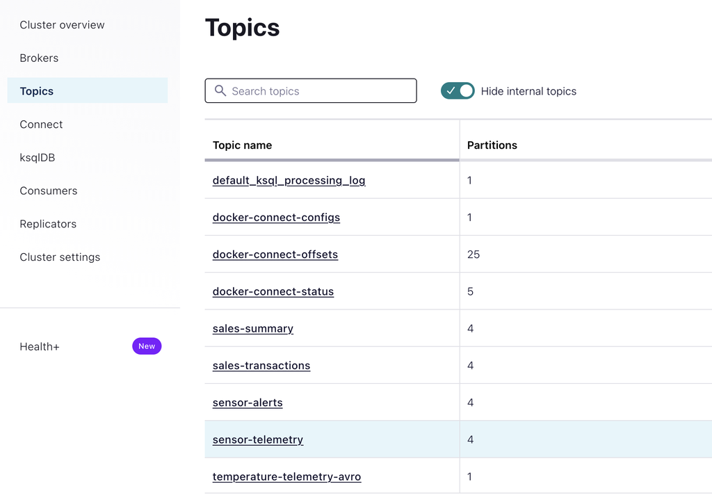

Control Center